# Project 7: Data Exploration and Visualization

### Overview

In this project, you will apply data exploration and visualization techniques to a real-world dataset of your choice. You'll practice using pandas for data analysis and create meaningful visualizations to gain insights from your data. This project builds on your Python programming skills while introducing you to the exciting world of data science.

In [Lab7](https://colab.research.google.com/drive/15QvSh0csZaCU-OuuPIfpWx5wLDDjmqK4?usp=sharing), you explore the titanic dataset and you should use it as a sample and pick a dataset of your interest to do a similar data exploration and visualization.

### Project Objectives

- Find and select a dataset from a real-world data source
- Formulate a clear inquiry question based on your chosen dataset
- Perform exploratory data analysis using pandas functions
- Create at least two meaningful data visualizations
- Analyze your findings and answer your inquiry question
- Reflect on the insights gained through data exploration

### Data Sources

You can choose from various online data sources such as:

- [Kaggle](https://www.kaggle.com/datasets) - Wide variety of datasets
- [data.gov](https://www.data.gov/) - U.S. government data
- [Our World in Data](https://ourworldindata.org/) - Global development data
- [GitHub](https://github.com/datasets) - Curated datasets
- [Google Dataset Search](https://datasetsearch.research.google.com/) - Search for datasets
- Or any other reliable data source you find interesting

## Part 1: Dataset Selection and Initial Exploration

#### TODO Tasks:

1. Select Your Dataset: Choose a dataset that interests you. Make sure it has at least 100 rows and multiple columns with different data types (e.g., numerical, categorical, dates).

Please create either text or code cells in between the TODO tasks to do the work.

2. Import Libraries: Import the necessary libraries (pandas, matplotlib, seaborn) at the beginning of your notebook by creating code cells below this text cell.

```python
import pandas as pd
import matplotlib.pyplot as plt
import seaborn as sns
```

3. Load Your Data: Load your chosen dataset using pandas and save it to a pandas dataframe. Please create a code cell below this text cell to do it.

```python
import kagglehub

# Download latest version
path = kagglehub.dataset_download("joannanplkrk/its-raining-cats")

print("Path to dataset files:", path)
```

```
Path to dataset files: /kaggle/input/its-raining-cats
```

```python
# Download latest version
path = kagglehub.dataset_download("joannanplkrk/its-raining-cats")

print("Path to dataset files:", path)

# Construct the full path to the CSV file using the downloaded path
csv_file_path = f'{path}/cat_breeds_clean.csv'

# Read the CSV file using the constructed path
cats_df = pd.read_csv(csv_file_path, sep=';')
```

```
Path to dataset files: /kaggle/input/its-raining-cats
```

4. Data Summary: Use the following functions to do inital exploration your dataset:
- info() - Display information about the dataset structure
- describe() - Show statistical summary of numerical columns
- head() - Display the first 5 rows (df.head())
- shape - Show the dimensions of the dataset (e.g. df.shape)
- columns - Get the column names (e.g. df.columns)

You may use 5 code cells below this text cell to accomplish it.

```python
# prompt: use the function info() to Display information about the dataset structure

cats_df.info()
```

```
<class 'pandas.core.frame.DataFrame'>
RangeIndex: 1071 entries, 0 to 1070
Data columns (total 17 columns):
 #   Column                   Non-Null Count  Dtype
---  ------                   --------------  -----
 0   Breed                    1071 non-null   object
 1   Age_in_years             1071 non-null   float64
 2   Age_in_months            1071 non-null   int64
 3   Gender                   1071 non-null   object
 4   Neutered_or_spayed       1071 non-null   bool
 5   Body_length              1071 non-null   int64
 6   Weight                   1071 non-null   float64
 7   Fur_colour_dominant      1071 non-null   object
 8   Fur_pattern              1071 non-null   object
 9   Eye_colour               1071 non-null   object
 10  Allowed_outdoor          1071 non-null   bool
 11  Preferred_food           1071 non-null   object
 12  Owner_play_time_minutes  1071 non-null   int64
 13  Sleep_time_hours         1071 non-null   int64
 14  Country                  1071 non-null   object
 15  Latitude                 1071 non-null   float64
 16  Longitude                1071 non-null   float64
dtypes: bool(2), float64(4), int64(4), object(7)
memory usage: 127.7+ KB
```

```python
cats_df.describe()
```

|  | Age_in_years | Age_in_months | Body_length | Weight | Owner_play_time_minutes | Sleep_time_hours | Latitude | Longitude |
| --- | --- | --- | --- | --- | --- | --- | --- | --- |
| count | 1071.000000 | 1071.000000 | 1071.000000 | 1071.000000 | 1071.000000 | 1071.000000 | 1071.000000 | 1071.000000 |
| mean | 4.845462 | 58.145658 | 44.003735 | 5.494613 | 23.049486 | 15.889823 | 44.439720 | -60.178554 |
| std | 2.737469 | 32.849889 | 16.310308 | 2.292242 | 10.840922 | 2.621443 | 4.965876 | 45.364141 |
| min | 0.080000 | 1.000000 | 10.000000 | 0.500000 | 0.000000 | 8.000000 | 37.774930 | -123.116226 |
| 25% | 2.670000 | 32.000000 | 35.000000 | 3.900000 | 14.000000 | 14.000000 | 40.714270 | -77.036370 |
| 50% | 4.920000 | 59.000000 | 41.000000 | 5.000000 | 23.000000 | 16.000000 | 42.358430 | -74.005970 |
| 75% | 7.040000 | 84.500000 | 51.000000 | 7.075000 | 31.000000 | 18.000000 | 48.864716 | -1.890401 |
| max | 11.250000 | 135.000000 | 102.000000 | 12.100000 | 60.000000 | 22.000000 | 53.800755 | 13.404954 |

```python
cats_df.head()
```

|  | Breed | Age_in_years | Age_in_months | Gender | Neutered_or_spayed | Body_length | Weight | Fur_colour_dominant | Fur_pattern | Eye_colour | Allowed_outdoor | Preferred_food | Owner_play_time_minutes | Sleep_time_hours | Country | Latitude | Longitude |
| --- | --- | --- | --- | --- | --- | --- | --- | --- | --- | --- | --- | --- | --- | --- | --- | --- | --- |
| 0 | Angora | 0.25 | 3 | female | False | 19 | 2.0 | white | solid | blue | False | wet | 46 | 16 | France | 43.296482 | 5.369780 |
| 1 | Angora | 0.33 | 4 | male | False | 19 | 2.5 | white | solid | blue | False | wet | 48 | 16 | France | 43.611660 | 3.877710 |
| 2 | Angora | 0.50 | 6 | male | False | 20 | 2.8 | black | solid | green | False | wet | 41 | 11 | France | 44.837789 | -0.579180 |
| 3 | Angora | 0.50 | 6 | female | False | 21 | 3.0 | white | solid | blue | False | wet | 24 | 8 | France | 43.611660 | 3.877710 |
| 4 | Angora | 0.50 | 6 | male | False | 21 | 3.0 | red/cream | tabby | green | False | wet | 51 | 10 | France | 48.864716 | 2.349014 |

```python
cats_df.shape
```

```
(1071, 17)
```

```python
cats_df.columns
```

```
Index(['Breed', 'Age_in_years', 'Age_in_months', 'Gender',
       'Neutered_or_spayed', 'Body_length', 'Weight', 'Fur_colour_dominant',
       'Fur_pattern', 'Eye_colour', 'Allowed_outdoor', 'Preferred_food',
       'Owner_play_time_minutes', 'Sleep_time_hours', 'Country', 'Latitude',
       'Longitude'],
      dtype='object')
```

5. Inquiry Question: Write a clear, specific question that you want to answer using your dataset by creating a text cell below and **write the question in bold please.**

For example:

- "How has the average temperature changed in major cities over the past decade?"
- "What factors are most strongly correlated with housing prices?"
- "Is there a relationship between education level and income?"

**What factors effect whether an owner choses to let their cat outside?**

## Part 2: Data Visualization and Analysis

#### TODO Tasks:

1. Data Cleaning (if necessary): Check for and handle any missing values, duplicates, or data quality issues.

**NOTE: This could be a daunting task even for seasoned data scientists. My suggestion is to use a dataset that is already clean if you can for the purpose of completing this assignment in a week.**

Examples:

- Checking for missing values: df.isnull().sum()
- Dropping rows with any missing values: df.dropna(inplace=True)
- Dropping columns with all missing values: df.dropna(axis=1, how='all', inplace=True)
- Removing duplicate row: df.drop_duplicates(inplace=True)
2. Create Visualizations: Create at least 2 different types of visualizations that help answer your research question. Choose from:
- Bar charts
- Line plots
- Scatter plots
- Histograms
- Box plots
- Heatmaps
- Any other appropriate visualization

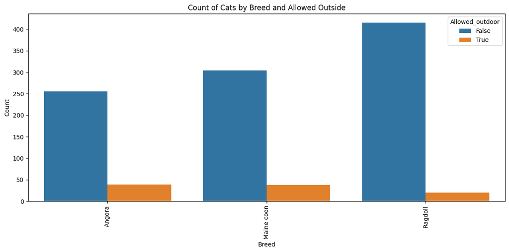

```python
# Assuming 'cats_df' is your DataFrame and it has 'Breed' and 'Allowed_outdoor' columns

# Use countplot with hue to show counts for combinations of the two variables
plt.figure(figsize=(12, 6)) # Adjust the figure size for readability if there are many breeds
sns.countplot(data=cats_df, x='Breed', hue='Allowed_outdoor')

# Add titles and labels for clarity
plt.title('Count of Cats by Breed and Allowed Outside')
plt.xlabel('Breed')
plt.ylabel('Count') # The y-axis now represents the count

# Display a legend to differentiate the hue categories
plt.legend(title='Allowed_outdoor')

# Rotate x-axis labels if there are many breeds to prevent overlap
plt.xticks(rotation=90)

# Adjust layout to prevent labels from being cut off
plt.tight_layout()

# Display the plot
plt.show()
```

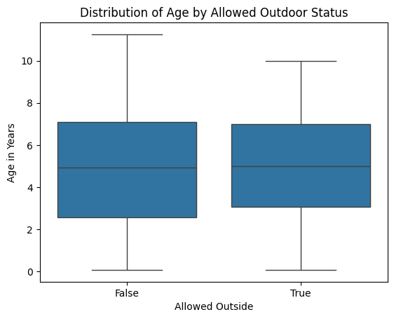

```python
sns.boxplot(data=cats_df, x='Allowed_outdoor', y='Age_in_years')

# Add titles and labels for clarity
plt.title('Distribution of Age by Allowed Outdoor Status')
plt.xlabel('Allowed Outside')
plt.ylabel('Age in Years')

# Display the plot
plt.show()
```

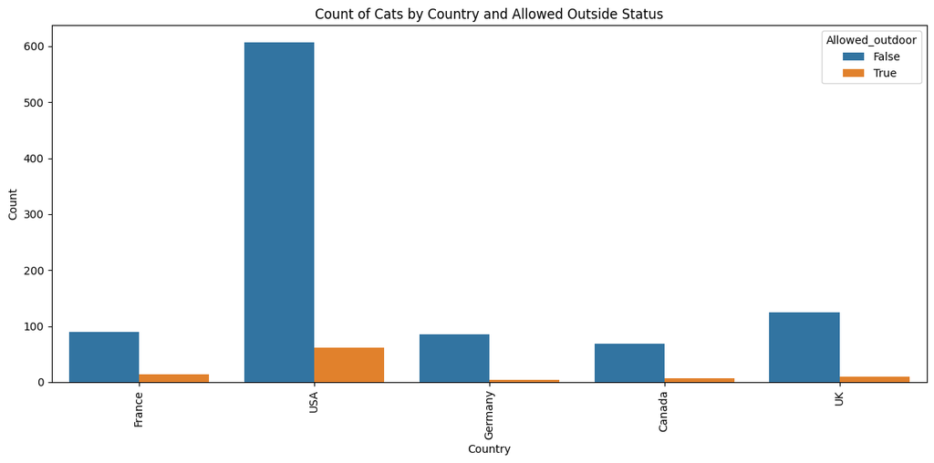

```python
# Create a countplot to show the counts for each country, separated by allowed outdoor status
plt.figure(figsize=(12, 6)) # Adjust the figure size for readability
sns.countplot(data=cats_df, x='Country', hue='Allowed_outdoor')

# Add titles and labels for clarity
plt.title('Count of Cats by Country and Allowed Outside Status')
plt.xlabel('Country')
plt.ylabel('Count')

# Add a legend
plt.legend(title='Allowed_outdoor')

# Rotate x-axis labels if there are many countries
plt.xticks(rotation=90)

# Adjust layout
plt.tight_layout()

# Display the plot
plt.show()
```

3. Customize Your Plots: Make sure your visualizations are clear and informative by:
- Adding appropriate titles
- Labeling axes
- Using colors effectively
- Adding legends when necessary

Please create code cells below this to create your visualizations.

4. Analysis: Write 1-2 paragraphs discussing:
- Whether your research question can be answered with the available data
- What insights you discovered through your visualizations
- Any unexpected or interesting findings
- Limitations of your analysis
- Suggestions for further investigation

Please create a text cell below this cell to write your analysis.

An interesting finding is the amount a cat sleeps. I have had a cat my entire life, and my family and I always joke about how much they sleep, but seeing evidence that this isn't just our cats is gratifying. Knowing that are cats aren't the only ones like this. A limitation to my research is what other factors affect whether a cat is aloud outside like if the owner has allergies or if they don't want fleas. A suggestion for further investigation is how many of these cats have had fleas, and how many of those cats are allowed outside.

## NOTE: If you use a local dataset, you MUST submit the dataset along with your notebook to get credit.

- Download your notebook as CS110_Project7.ipynb
- Ensure all TODO tasks are completed
- Make sure your code runs without errors
- Include clear comments explaining your work
- Submit the notebook file

## Grading Criteria (4 points)

- Dataset Selection: Appropriate choice of dataset with sufficient complexity
- Inquiry Question: Clear, specific, and answerable with the chosen data
- Data Exploration: Proper use of pandas functions for initial analysis
- Visualizations: At least 2 clear, well-formatted, and relevant plots
- Analysis: Thoughtful interpretation of findings and answer to research question
- Code Quality: Clean, commented, and well-organized code

Remember: The goal is not just to create visualizations, but to use them to gain meaningful insights about your data. Think like a data scientist and let your curiosity guide your exploration!